# Indexing, Data Wrangling, Plots

Alexander Troynin

03 05 2018

Попытаемся определить индекс уровня убийств который меньше или равно 0.71.

```r
murder_rate <- murders$total/murders$population * 100000
index <- murder_rate <= 0.71
print(index)
```

```
##  [1] FALSE FALSE FALSE FALSE FALSE FALSE FALSE FALSE FALSE FALSE FALSE
## [12]  TRUE FALSE FALSE FALSE  TRUE FALSE FALSE FALSE FALSE FALSE FALSE
## [23] FALSE FALSE FALSE FALSE FALSE FALSE FALSE  TRUE FALSE FALSE FALSE
## [34] FALSE  TRUE FALSE FALSE FALSE FALSE FALSE FALSE FALSE FALSE FALSE
## [45] FALSE  TRUE FALSE FALSE FALSE FALSE FALSE
```

Мы получили 51 индекс логических значений который можем использовать для получения штатов уровень убийств которых меньше 0.71.

```r
print(murders$state[index])
```

```
## [1] "Hawaii"        "Iowa"          "New Hampshire" "North Dakota"
## [5] "Vermont"
```

which дает нам индекс логического вектора значения которых равны истине.

```r
print(which(index))
```

```
## [1] 12 16 30 35 46
```

match функция сообщает нам, какие индексы второго вектора соответствуют каждой из записей первого вектора.

```r
index <- match(c("New York", "Florida", "Texas"), murders$state)
print(index)
```

```
## [1] 33 10 44
```

```r
print(murders$state[index])
```

```
## [1] "New York" "Florida"  "Texas"
```

Если вместо индекса мы хотим знать, будет ли каждый элемент первого вектор находится во втором векторе, мы используем функцию %in%.

```r
x <- c("a", "b", "c", "d")
y <- c("a", "b", "f")
print(y %in% x)
```

```
## [1]  TRUE  TRUE FALSE
```

Для работы с базой данных в R есть пакет dplyr.

```r
install.packages("dplyr")
library(dplyr)
```

Чтобы изменить таблицу данных, добавив новый столбец или изменить существующий, мы используем mutate.

```r
print(str(murders))
```

```
## 'data.frame':    51 obs. of  5 variables:
##  $ state     : chr  "Alabama" "Alaska" "Arizona" "Arkansas" ...
##  $ abb       : chr  "AL" "AK" "AZ" "AR" ...
##  $ region    : Factor w/ 4 levels "Northeast","South",..: 2 4 4 2 4 4 1 2 2 2 ...
##  $ population: num  4779736 710231 6392017 2915918 37253956 ...
##  $ total     : num  135 19 232 93 1257 ...
## NULL
```

```r
murders <- mutate(murders, rate=total/population * 100000)
print(str(murders))
```

```
## 'data.frame':    51 obs. of  6 variables:
##  $ state     : chr  "Alabama" "Alaska" "Arizona" "Arkansas" ...
##  $ abb       : chr  "AL" "AK" "AZ" "AR" ...
##  $ region    : Factor w/ 4 levels "Northeast","South",..: 2 4 4 2 4 4 1 2 2 2 ...
##  $ population: num  4779736 710231 6392017 2915918 37253956 ...
##  $ total     : num  135 19 232 93 1257 ...
##  $ rate      : num  2.82 2.68 3.63 3.19 3.37 ...
## NULL
```

Чтобы фильтровать данные по подмножествам строк, мы используем filter.

```r
print(filter(murders, rate <= 0.71))
```

```
##           state abb        region population total      rate
## 1        Hawaii  HI          West    1360301     7 0.5145920
## 2          Iowa  IA North Central    3046355    21 0.6893484
## 3 New Hampshire  NH     Northeast    1316470     5 0.3798036
## 4  North Dakota  ND North Central     672591     4 0.5947151
## 5       Vermont  VT     Northeast     625741     2 0.3196211
```

А для подмножества данных путем выбора конкретных столбцов мы используем select.

```r
new_table <- select(murders, state, region, rate)
print(filter(new_table, rate <= 0.71))
```

```
##           state        region      rate
## 1        Hawaii          West 0.5145920
## 2          Iowa North Central 0.6893484
## 3 New Hampshire     Northeast 0.3798036
## 4  North Dakota North Central 0.5947151
## 5       Vermont     Northeast 0.3196211
```

Мы можем создать data frame в R.

```r
grades <- data.frame(names=c("John", "Juan", "Jean", "Yao"),
                     exam_1 = c(95, 80, 90, 85),
                     exam_2 = c(90, 85, 85, 90))
print(grades)
```

```
##   names exam_1 exam_2
## 1  John     95     90
## 2  Juan     80     85
## 3  Jean     90     85
## 4   Yao     85     90
```

По умолчанию data frame превращает символы в факторы.

```r
print(class(grades$names))
```

```
## [1] "factor"
```

Чтобы избежать этого мы используем AsFactors.

```r
grades <- data.frame(names=c("John", "Juan", "Jean", "Yao"),
                     exam_1 = c(95, 80, 90, 85),
                     exam_2 = c(90, 85, 85, 90),
                     stringsAsFactors = FALSE)
print(class(grades$names))
```

```
## [1] "character"
```

rank производит выборку значения ранга в векторе и возвращает его.

```r
murders <- mutate(murders, rate = total/population * 100000, rank = rank(-rate))
print(filter(murders, rank < 6))
```

```
##                  state abb        region population total      rate rank
## 1 District of Columbia  DC         South     601723    99 16.452753    1
## 2            Louisiana  LA         South    4533372   351  7.742581    2
## 3             Maryland  MD         South    5773552   293  5.074866    4
## 4             Missouri  MO North Central    5988927   321  5.359892    3
## 5       South Carolina  SC         South    4625364   207  4.475323    5
```

nrow/ncol возвращает номер строк/колон хранимых в массиве.

```r
nrow(murders)
```

```
## [1] 51
```

%>% линейный оператор, позволяет одни данные обрабатывать несколькими функциями записывая в одну строку.

```r
my_states <- murders %>% mutate(rate =  total / population * 100000, rank = rank(-rate)) %>% filter(region %in% c("Northeast", "West") & rate < 1) %>% select(state, rate, rank)
print(my_states)
```

```
##           state      rate rank
## 1        Hawaii 0.5145920   49
## 2         Idaho 0.7655102   46
## 3         Maine 0.8280881   44
## 4 New Hampshire 0.3798036   50
## 5        Oregon 0.9396843   42
## 6          Utah 0.7959810   45
## 7       Vermont 0.3196211   51
## 8       Wyoming 0.8871131   43
```

Визуализация возможно является главной силой R.

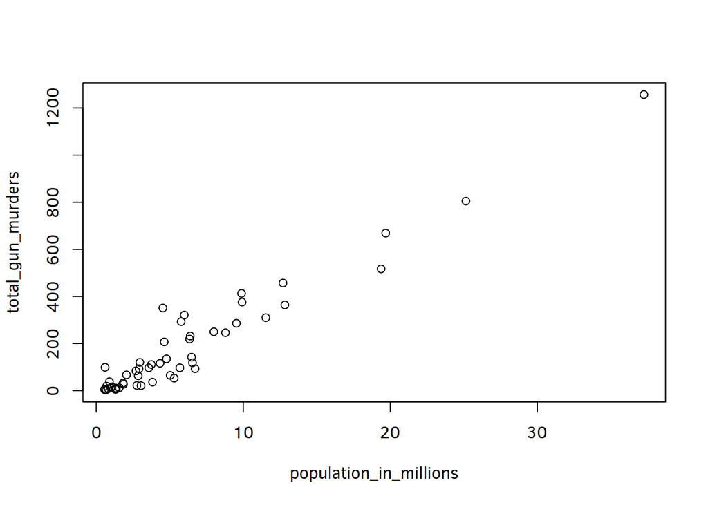

```r
population_in_millions <- murders$population / 10^6
total_gun_murders <- murders$total
plot(population_in_millions, total_gun_murders)
```

Гистограммы являются мощными графическими сводками списка чисел, который дает общий обзор типов значений которые есть.

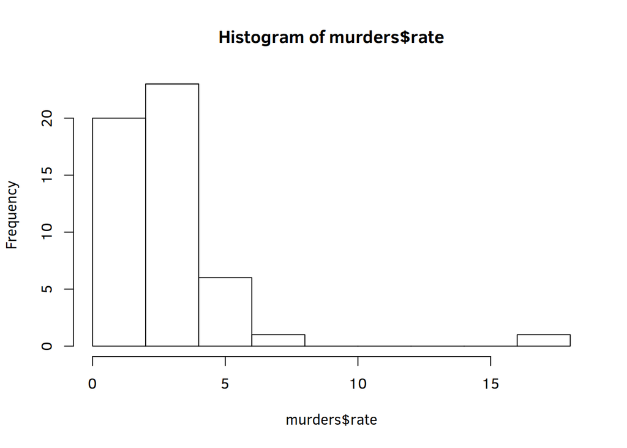

```r
hist(murders$rate)
```

Box plot дают более краткий обзор чем гистораммы, ни их легче сравнивать друг с другом.

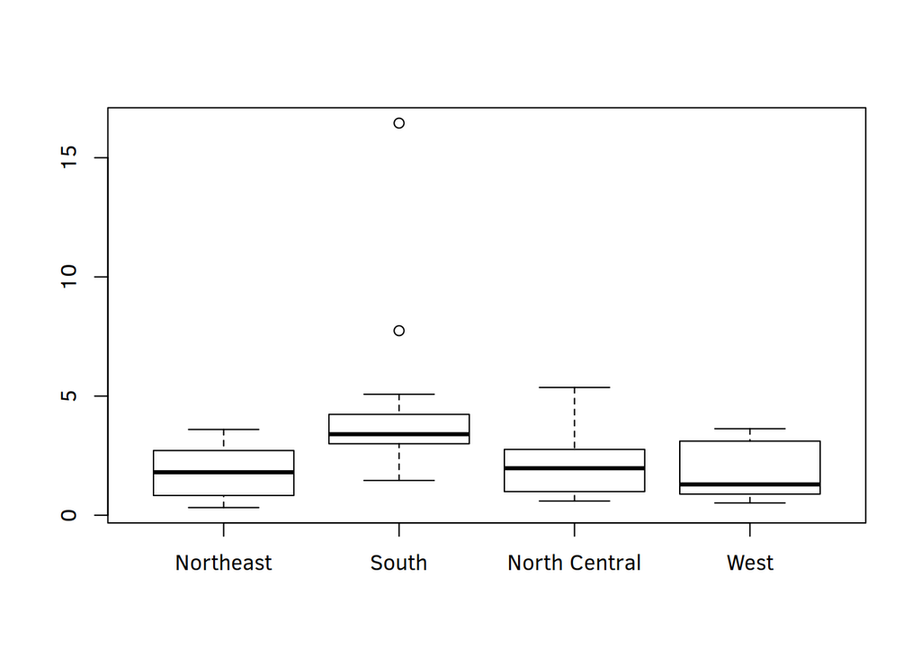

```r
boxplot(rate~region, data = murders)
```